# 備忘録_from2025_July_14

## 1015

### 全植物ホルモン遺伝子のPAML

```bash
### bs_lrp.py

import os
import re
from scipy.stats import chi2

def parse_lnL(file_path):
    """
    codeml出力ファイルから lnL と np を抽出する。
    成功すれば (np, lnL)、失敗すれば (None, None, error_message) を返す。
    """
    try:
        with open(file_path, 'r') as f:
            for line in f:
                match = re.search(r'lnL\(ntime:\s*\d+\s+np:\s*(\d+)\):\s*(-?\d+\.\d+)', line)
                if match:
                    np = int(match.group(1))
                    lnL = float(match.group(2))
                    return np, lnL, None
        return None, None, f"lnL行が見つかりません ({file_path})"
    except Exception as e:
        return None, None, f"ファイル読み込みエラー ({file_path}): {e}"

def perform_lrt(alt_lnL, alt_np, null_lnL, null_np):
    lr_stat = 2 * (alt_lnL - null_lnL)
    df = alt_np - null_np
    p_val = chi2.sf(lr_stat, df)
    return p_val

def main():
    alt_dir = '/home/kosukesano/tools/for_paml/251014/APH/bsA/result'
    null_dir = '/home/kosukesano/tools/for_paml/251014/APH/bsN/result'
    output_file = 'branch_site_lrt_results.txt'

    og_files = [f for f in os.listdir(alt_dir) if f.endswith('_bsa.txt')]

    positive_selection_count = 0
    missing_files = 0
    parse_errors = 0
    processed = 0

    with open(output_file, 'w') as out_f:
        out_f.write('OG_num\tp_val\tpositive_selection\tmessage\n')

        for og_file in og_files:
            og_num = og_file.replace('_bsa.txt', '')
            alt_file = os.path.join(alt_dir, og_file)
            null_file = os.path.join(null_dir, f'{og_num}_bsn.txt')

            if not os.path.exists(alt_file):
                out_f.write(f'{og_num}\tNA\tNA\taltファイルが存在しません\n')
                missing_files += 1
                continue
            if not os.path.exists(null_file):
                out_f.write(f'{og_num}\tNA\tNA\tnullファイルが存在しません\n')
                missing_files += 1
                continue

            alt_np, alt_lnL, alt_err = parse_lnL(alt_file)
            null_np, null_lnL, null_err = parse_lnL(null_file)

            if alt_err or null_err:
                err_msg = alt_err if alt_err else null_err
                out_f.write(f'{og_num}\tNA\tNA\t{err_msg}\n')
                parse_errors += 1
                continue

            # 正常に読み取れた場合
            p_val = perform_lrt(alt_lnL, alt_np, null_lnL, null_np)
            reject_null = '+' if p_val < 0.05 else '-'
            if reject_null == '+':
                positive_selection_count += 1
            out_f.write(f'{og_num}\t{p_val:.5e}\t{reject_null}\tOK\n')
            processed += 1

    # サマリー出力
    print(f'処理完了: {processed} OG')
    print(f'正の選択が検出された遺伝子数: {positive_selection_count}')
    print(f'ファイル欠損数: {missing_files}')
    print(f'解析失敗数（lnL行未検出など）: {parse_errors}')
    print(f'詳細は {output_file} を参照してください。')

if __name__ == "__main__":
    main()
```

このスクリプトを実行

```bash
kosukesano@a001:~/tools/for_paml/251014/APH$ python bs_lrp.py
処理完了: 57 OG
正の選択が検出された遺伝子数: 1
ファイル欠損数: 0
解析失敗数（lnL行未検出など）: 33
詳細は branch_site_lrt_results.txt を参照してください。
kosukesano@a001:~/tools/for_paml/251014/APH$
```

1個取れてる

```bash
OG0005782.fasta_1       1.05838e-02     +       OK
```

```bash
e3  Smad_g6011.t1   OG0005782
```

e3はこういう遺伝子  
**tRNA-2-methylthio-N6-dimethylallyladenosine synthase**  
[論文ここ](https://link.springer.com/article/10.1007/s11829-023-10022-9/tables/1)

### PAMLがうまくいかなかった遺伝子を探す

```bash
### check_lnL.py

import os
import re

# ======== 設定 ========
branch_site_file = "branch_site_lrt_results.txt"
log_dir = "bsA/log"
output_file = "missing_lnL_logs.txt"
# ======================


def get_missing_lnL_ognums(filepath):
    """
    branch_site_lrt_results.txt から "lnL行が見つかりません" を含む行の OG_num を抽出
    """
    ognums = []
    with open(filepath, "r", encoding="utf-8") as f:
        header = next(f)  # ヘッダーをスキップ
        for line in f:
            cols = line.strip().split("\t")
            if len(cols) < 4:
                continue
            og, _, _, msg = cols[:4]
            if "lnL行が見つかりません" in msg:
                ognums.append(og)
    return ognums


def search_logs_and_output(ognums, log_dir, output_file):
    """
    bsA/log 内の *.out.log ファイルを調べ、
    OG_num を含むものの最後の5行を標準出力とファイルに出力
    """
    with open(output_file, "w", encoding="utf-8") as out_f:
        for log_file in sorted(os.listdir(log_dir)):
            if not log_file.endswith(".out.log"):
                continue
            log_path = os.path.join(log_dir, log_file)
            try:
                with open(log_path, "r", encoding="utf-8") as f:
                    first_line = f.readline().strip()
                    # どの OG_num とも一致するかチェック
                    for og in ognums:
                        if og in first_line:
                            lines = f.readlines()
                            last_lines = "".join(lines[-5:]) if len(lines) >= 5 else "".join(lines)
                            result_text = (
                                f"=== {log_file} ({og}) ===\n"
                                f"{last_lines}\n"
                            )
                            print(result_text)
                            out_f.write(result_text)
                            break
            except Exception as e:
                print(f"Error reading {log_path}: {e}")


if __name__ == "__main__":
    # ステップ1: OG_num の抽出
    missing_ogs = get_missing_lnL_ognums(branch_site_file)
    print(f"検出された 'lnL行が見つかりません' のOG数: {len(missing_ogs)}")

    # ステップ2: ログ探索と出力
    search_logs_and_output(missing_ogs, log_dir, output_file)

    print(f"\n出力を {output_file} に保存しました。")
```

実行結果はmissing_lnL_logs.txtに保存された。

### 配列ファイルが無い種は種系統樹を書き換えて実行する

PAMLのエラーは配列ファイルと種系統樹の不一致が原因っぽい。配列ファイルを読み込むときに不足している種を取得し、それを種系統樹から除くようにスクリプトを改造する。

`newick_util`を使用する。

系統樹の先頭の種だけはうまく切り取れないっぽかったので、それは別途系統樹を作っておく。

```bash
kosukesano@a001:~/tools/for_paml/251015/APH_test$ apptainer exec /usr/local/biotools/n/newick_utils:1.6--hec16e2b_6 nw_topology tree_noDmel.nwk >tree_noDmel2.nwk
kosukesano@a001:~/tools/for_paml/251015/APH_test$
```

**bsA**

```bash
#!/bin/bash
#SBATCH --job-name=bsA_array
#SBATCH --cpus-per-task=1
#SBATCH --partition=short
#SBATCH --time=1:00:00
#SBATCH --array=1-90
#SBATCH --error=/home/kosukesano/tools/for_paml/251015/APH_test2/bsA/log/%x_%A_%a.err.log
#SBATCH --output=/home/kosukesano/tools/for_paml/251015/APH_test2/bsA/log/%x_%A_%a.out.log

######### 設定 #########
FASTA_DIR="/home/kosukesano/tools/for_paml/251015/APH_test2/data"
TREE_FILE_BASE="/home/kosukesano/tools/for_paml/251015/APH_test2/tree.txt"
TREE_FILE_ALT="/home/kosukesano/tools/for_paml/251015/APH_test2/tree_noDmel2.nwk"
OUT_DIR="/home/kosukesano/tools/for_paml/251015/APH_test2/bsA/result"
CTL_DIR="/home/kosukesano/tools/for_paml/251015/APH_test2/bsA/ctl"
WORK_DIR="/home/kosukesano/tools/for_paml/251015/APH_test2/bsA"
FILE_LIST="${FASTA_DIR}/file_list.txt"
TREE_TMP_DIR="${WORK_DIR}/tree_tmp"

mkdir -p "$OUT_DIR" "$CTL_DIR" "$WORK_DIR/log" "$TREE_TMP_DIR"

######### JOB配列番号 #########
SEQ_FILE_NAME=$(sed -n "${SLURM_ARRAY_TASK_ID}p" "$FILE_LIST")
SEQ_FILE="${FASTA_DIR}/${SEQ_FILE_NAME}"
BASENAME=$(basename "$SEQ_FILE_NAME" .fna)
OUT_FILE="${OUT_DIR}/${BASENAME}_bsa.txt"
CTL_FILE="${CTL_DIR}/${BASENAME}_bsa.ctl"

echo "=== Running codeml for ${SEQ_FILE_NAME} (Task ID: ${SLURM_ARRAY_TASK_ID}) ==="

######### FASTA中の種名を抽出 #########
FASTA_SPECIES=($(grep '^>' "$SEQ_FILE" | sed 's/>//' | awk '{print $1}' | sort -u))
echo "  → FASTAに含まれる種: ${FASTA_SPECIES[*]}"

######### Dmelが含まれるか確認 #########
if printf '%s\n' "${FASTA_SPECIES[@]}" | grep -qx "Dmel"; then
    TREE_FILE="$TREE_FILE_BASE"
    echo "  → Dmelを検出しました。通常のツリー (${TREE_FILE}) を使用します。"
else
    TREE_FILE="$TREE_FILE_ALT"
    echo "  → Dmelが含まれません。ツリーを ${TREE_FILE_ALT} に切り替えます。"
fi

######### 系統樹中の種を抽出 #########
TREE_SPECIES=($(grep -oE '[A-Za-z0-9_]+' "$TREE_FILE" | sort -u))

######### 不一致種を検出 #########
MISSING_SPECIES=()
for sp in "${TREE_SPECIES[@]}"; do
    if ! printf '%s\n' "${FASTA_SPECIES[@]}" | grep -qx "$sp"; then
        MISSING_SPECIES+=("$sp")
    fi
done

######### prune処理 #########
TREE_FOR_RUN="$TREE_FILE"
if [ ${#MISSING_SPECIES[@]} -gt 0 ]; then
    echo "  → FASTAに存在しない種をツリーから除外します: ${MISSING_SPECIES[*]}"
    PRUNED_TREE="${TREE_TMP_DIR}/${BASENAME}_tree_pruned.nwk"
    cp "$TREE_FILE" "$PRUNED_TREE"
    for sp in "${MISSING_SPECIES[@]}"; do
        apptainer exec /usr/local/biotools/n/newick_utils:1.6--hec16e2b_6 \
            nw_prune "$PRUNED_TREE" "$sp" > "${PRUNED_TREE}.tmp"
        mv "${PRUNED_TREE}.tmp" "$PRUNED_TREE"
    done
    TREE_FOR_RUN="$PRUNED_TREE"
else
    echo "  → 全ての種が一致しています。元のツリーを使用します。"
fi

######### CTLファイル生成 #########
cat > "$CTL_FILE" <<EOF
      seqfile = $SEQ_FILE
     treefile = $TREE_FOR_RUN
      outfile = $OUT_FILE

        noisy = 9
      verbose = 1
      runmode = 0

      seqtype = 1
    CodonFreq = 2
        clock = 0
        model = 2

      NSsites = 2
        icode = 0

    fix_kappa = 0
        kappa = 2
    fix_omega = 0
        omega = 1

    fix_alpha = 1
        alpha = .0
       Malpha = 0
        ncatG = 4

        getSE = 0
 RateAncestor = 0
       method = 0
  fix_blength = 0
EOF

######### codeml実行 #########
echo "  → codemlを実行中..."
apptainer exec -e /usr/local/biotools/p/paml:4.9--h779adbc_6 codeml "$CTL_FILE"

######### 終了 #########
echo "=== Done: ${SEQ_FILE_NAME} ==="
```

**bsN**

```bash
#!/bin/bash
#SBATCH --job-name=bsN_array
#SBATCH --cpus-per-task=1
#SBATCH --partition=short
#SBATCH --time=1:00:00
#SBATCH --array=1-90
#SBATCH --error=/home/kosukesano/tools/for_paml/251015/APH_test2/bsN/log/%x_%A_%a.err.log
#SBATCH --output=/home/kosukesano/tools/for_paml/251015/APH_test2/bsN/log/%x_%A_%a.out.log

######### 設定 #########
FASTA_DIR="/home/kosukesano/tools/for_paml/251015/APH_test2/data"
TREE_FILE_BASE="/home/kosukesano/tools/for_paml/251015/APH_test2/tree.txt"
TREE_FILE_ALT="/home/kosukesano/tools/for_paml/251015/APH_test2/tree_noDmel2.nwk"
OUT_DIR="/home/kosukesano/tools/for_paml/251015/APH_test2/bsN/result"
CTL_DIR="/home/kosukesano/tools/for_paml/251015/APH_test2/bsN/ctl"
WORK_DIR="/home/kosukesano/tools/for_paml/251015/APH_test2/bsN"
FILE_LIST="${FASTA_DIR}/file_list.txt"
TREE_TMP_DIR="${WORK_DIR}/tree_tmp"

mkdir -p "$OUT_DIR" "$CTL_DIR" "$WORK_DIR/log" "$TREE_TMP_DIR"

######### JOB配列番号 #########
SEQ_FILE_NAME=$(sed -n "${SLURM_ARRAY_TASK_ID}p" "$FILE_LIST")
SEQ_FILE="${FASTA_DIR}/${SEQ_FILE_NAME}"
BASENAME=$(basename "$SEQ_FILE_NAME" .fna)
OUT_FILE="${OUT_DIR}/${BASENAME}_bsn.txt"
CTL_FILE="${CTL_DIR}/${BASENAME}_bsn.ctl"

echo "=== Running codeml for ${SEQ_FILE_NAME} (Task ID: ${SLURM_ARRAY_TASK_ID}) ==="

######### FASTA中の種名を抽出 #########
FASTA_SPECIES=($(grep '^>' "$SEQ_FILE" | sed 's/>//' | awk '{print $1}' | sort -u))
echo "  → FASTAに含まれる種: ${FASTA_SPECIES[*]}"

######### Dmelが含まれるか確認 #########
if printf '%s\n' "${FASTA_SPECIES[@]}" | grep -qx "Dmel"; then
    TREE_FILE="$TREE_FILE_BASE"
    echo "  → Dmelを検出しました。通常のツリー (${TREE_FILE}) を使用します。"
else
    TREE_FILE="$TREE_FILE_ALT"
    echo "  → Dmelが含まれません。ツリーを ${TREE_FILE_ALT} に切り替えます。"
fi

######### 系統樹中の種を抽出 #########
TREE_SPECIES=($(grep -oE '[A-Za-z0-9_]+' "$TREE_FILE" | sort -u))

######### 不一致種を検出 #########
MISSING_SPECIES=()
for sp in "${TREE_SPECIES[@]}"; do
    if ! printf '%s\n' "${FASTA_SPECIES[@]}" | grep -qx "$sp"; then
        MISSING_SPECIES+=("$sp")
    fi
done

######### prune処理 #########
TREE_FOR_RUN="$TREE_FILE"
if [ ${#MISSING_SPECIES[@]} -gt 0 ]; then
    echo "  → FASTAに存在しない種をツリーから除外します: ${MISSING_SPECIES[*]}"
    PRUNED_TREE="${TREE_TMP_DIR}/${BASENAME}_tree_pruned.nwk"
    cp "$TREE_FILE" "$PRUNED_TREE"
    for sp in "${MISSING_SPECIES[@]}"; do
        apptainer exec /usr/local/biotools/n/newick_utils:1.6--hec16e2b_6 \
            nw_prune "$PRUNED_TREE" "$sp" > "${PRUNED_TREE}.tmp"
        mv "${PRUNED_TREE}.tmp" "$PRUNED_TREE"
    done
    TREE_FOR_RUN="$PRUNED_TREE"
else
    echo "  → 全ての種が一致しています。元のツリーを使用します。"
fi

######### CTLファイル生成 #########
cat > "$CTL_FILE" <<EOF
      seqfile = $SEQ_FILE
     treefile = $TREE_FOR_RUN
      outfile = $OUT_FILE

        noisy = 9
      verbose = 1
      runmode = 0

      seqtype = 1
    CodonFreq = 2
        clock = 0
        model = 2

      NSsites = 2
        icode = 0

    fix_kappa = 0
        kappa = 2
    fix_omega = 1
        omega = 1

    fix_alpha = 1
        alpha = .0
       Malpha = 0
        ncatG = 4

        getSE = 0
 RateAncestor = 0
       method = 0
  fix_blength = 0
EOF

######### codeml実行 #########
echo "  → codemlを実行中..."
apptainer exec -e /usr/local/biotools/p/paml:4.9--h779adbc_6 codeml "$CTL_FILE"

######### 終了 #########
echo "=== Done: ${SEQ_FILE_NAME} ==="
```

結果

```bash
kosukesano@a001:~/tools/for_paml/251015/APH_test2$ python bs_lrp.py
処理完了: 85 OG
正の選択が検出された遺伝子数: 1
ファイル欠損数: 0
解析失敗数（lnL行未検出など）: 5
詳細は branch_site_lrt_results.txt を参照してください。
kosukesano@a001:~/tools/for_paml/251015/APH_test2$
```

まだ完全じゃ無いけどマシにはなってる。

## 1016

### CK_IAA遺伝子のDEG

青色が幼虫高発現、赤色が成虫高発現

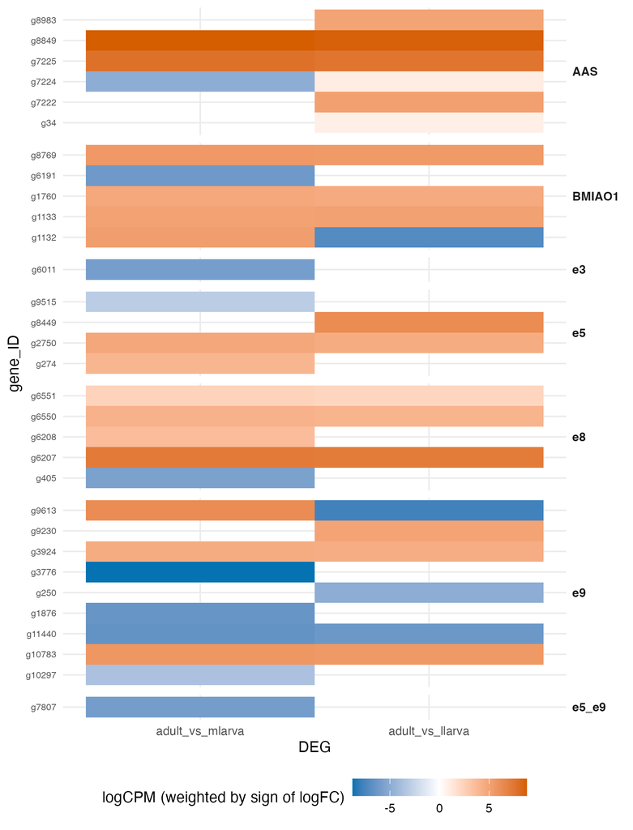

## 1017

### PAMLで取れてきた遺伝子が食い違っている？

`~/tools/for_paml/251014/APH`の結果と`~/tools/for_paml/251015/APH_test2`の結果で、正の選択が検出された遺伝子が食い違っている。

```bash
### /home/kosukesano/tools/for_paml/251014/APH/branch_site_lrt_results.txt
OG0005782.fasta_1   1.05838e-02 +   OK
OG0000564.fasta_2   1.00000e+00 -   OK
```

```bash
OG0005782.fasta_1   1.00000e+00 -   OK
OG0000564.fasta_2   4.93757e-04 +   OK
```

`data/`内の配列を確認してみる

```bash
kosukesano@a001:~/tools/for_paml/251014/APH$ apptainer exec -e /usr/local/biotools/s/seqkit\:2.5.0--h9ee0642_0 seqkit stat data/OG0005782.fasta_1.fna
file                        format  type  num_seqs  sum_len  min_len  avg_len  max_len
data/OG0005782.fasta_1.fna  FASTA   DNA         13   20,631    1,587    1,587    1,587
kosukesano@a001:~/tools/for_paml/251014/APH$ apptainer exec -e /usr/local/biotools/s/seqkit\:2.5.0--h9ee0642_0 seqkit stat data/OG0000564.fasta_2.fna
file                        format  type  num_seqs  sum_len  min_len  avg_len  max_len
data/OG0000564.fasta_2.fna  FASTA   DNA         13   11,193      861      861      861
kosukesano@a001:~/tools/for_paml/251014/APH$
```

```bash
kosukesano@a001:~/tools/for_paml/251015/APH_test2$ apptainer exec -e /usr/local/biotools/s/seqkit\:2.5.0--h9ee0642_0 seqkit stat data/OG0005782.fasta_1.fna
file                        format  type  num_seqs  sum_len  min_len  avg_len  max_len
data/OG0005782.fasta_1.fna  FASTA   DNA         13   20,631    1,587    1,587    1,587
kosukesano@a001:~/tools/for_paml/251015/APH_test2$ apptainer exec -e /usr/local/biotools/s/seqkit\:2.5.0--h9ee0642_0 seqkit stat data/OG0000564.fasta_2.fna
file                        format  type  num_seqs  sum_len  min_len  avg_len  max_len
data/OG0000564.fasta_2.fna  FASTA   DNA         13   11,193      861      861      861
kosukesano@a001:~/tools/for_paml/251015/APH_test2$
```

ファイルは同じ？

**251014/APH/の結果**

564_2

```bash
### bsA
CODONML (in paml version 4.9, March 2015)  /home/kosukesano/tools/for_paml/251014/APH/data/OG0000564.fasta_2.fna
Model: several dN/dS ratios for branches for branches,
Codon frequency model: F3x4
Site-class models:  PositiveSelection
ns =  13  ls = 287
REE #  1:  (3, (4, (13, ((11, ((6, 12), ((9, (1, (7, 8))), (2, 10)))), 5))));   MP score: -1
This is a rooted tree.  Please check!
lnL(ntime: 24  np: 29):  -7829.543658      +0.000000

###bsN
CODONML (in paml version 4.9, March 2015)  /home/kosukesano/tools/for_paml/251014/APH/data/OG0000564.fasta_2.fna
Model: several dN/dS ratios for branches for branches,  omega = 1.000 fixed

Codon frequency model: F3x4
Site-class models:  PositiveSelection
ns =  13  ls = 287
TREE #  1:  (3, (4, (13, ((11, ((6, 12), ((9, (1, (7, 8))), (2, 10)))), 5))));   MP score: -1
This is a rooted tree.  Please check!
lnL(ntime: 24  np: 28):  -7823.474108      +0.000000
```

**251015/APH_test2/の結果**

564_2

```bash
### bsA
CODONML (in paml version 4.9, March 2015)  /home/kosukesano/tools/for_paml/251015/APH_test2/data/OG0000564.fasta_2.fna
Model: several dN/dS ratios for branches for branches,
Codon frequency model: F3x4
Site-class models:  PositiveSelection
ns =  13  ls = 287
TREE #  1:  (3, (4, (13, ((11, ((6, 12), ((9, (1, (7, 8))), (2, 10)))), 5))));   MP score: -1
This is a rooted tree.  Please check!
check convergence..
lnL(ntime: 24  np: 29):  -7823.474109      +0.000000

###bsN
CODONML (in paml version 4.9, March 2015)  /home/kosukesano/tools/for_paml/251015/APH_test2/data/OG0000564.fasta_2.fna
Model: several dN/dS ratios for branches for branches,  omega = 1.000 fixed

Codon frequency model: F3x4
Site-class models:  PositiveSelection
ns =  13  ls = 287
TREE #  1:  (3, (4, (13, ((11, ((6, 12), ((9, (1, (7, 8))), (2, 10)))), 5))));   MP score: -1
This is a rooted tree.  Please check!
check convergence..
lnL(ntime: 24  np: 28):  -7829.543658      +0.000000
```

5782

```bash
### bsA
CODONML (in paml version 4.9, March 2015)  /home/kosukesano/tools/for_paml/251014/APH/data/OG0005782.fasta_1.fna
Model: several dN/dS ratios for branches for branches,
Codon frequency model: F3x4
Site-class models:  PositiveSelection
ns =  13  ls = 529
TREE #  1:  (4, (13, (12, ((9, ((2, 5), ((8, (7, (3, 6))), (1, 10)))), 11))));   MP score: -1
This is a rooted tree.  Please check!
lnL(ntime: 24  np: 29): -12574.938455      +0.000000

### bsN
CODONML (in paml version 4.9, March 2015)  /home/kosukesano/tools/for_paml/251014/APH/data/OG0005782.fasta_1.fna
Model: several dN/dS ratios for branches for branches,  omega = 1.000 fixed

Codon frequency model: F3x4
Site-class models:  PositiveSelection
ns =  13  ls = 529
TREE #  1:  (4, (13, (12, ((9, ((2, 5), ((8, (7, (3, 6))), (1, 10)))), 11))));   MP score: -1
This is a rooted tree.  Please check!
lnL(ntime: 24  np: 28): -12578.205404      +0.000000
```

5782

```bash
### bsA
CODONML (in paml version 4.9, March 2015)  /home/kosukesano/tools/for_paml/251015/APH_test2/data/OG0005782.fasta_1.fna
Model: several dN/dS ratios for branches for branches,
Codon frequency model: F3x4
Site-class models:  PositiveSelection
ns =  13  ls = 529
TREE #  1:  (4, (13, (12, ((9, ((2, 5), ((8, (7, (3, 6))), (1, 10)))), 11))));   MP score: -1
This is a rooted tree.  Please check!
check convergence..
lnL(ntime: 24  np: 29): -12574.938455      +0.000000

### bsN
CODONML (in paml version 4.9, March 2015)  /home/kosukesano/tools/for_paml/251015/APH_test2/data/OG0005782.fasta_1.fna
Model: several dN/dS ratios for branches for branches,  omega = 1.000 fixed
Codon frequency model: F3x4
Site-class models:  PositiveSelection
ns =  13  ls = 529
TREE #  1:  (4, (13, (12, ((9, ((2, 5), ((8, (7, (3, 6))), (1, 10)))), 11))));   MP score: -1
This is a rooted tree.  Please check!
check convergence..
lnL(ntime: 24  np: 28): -12574.938455      +0.000000
```

251015/APH/test2で系統樹いじったのがあかんかった気がする。FASTAの並び替えとかもしてたからその辺で整合性が取れなくなったか？

### 系統樹を事前に作成した上でPAMLを実行する

まずオーソログの中で欠けのある種をリストアップする

```bash
### /home/kosukesano/tools/for_paml/251017/test/check_species.sh

#!/bin/bash
set -euo pipefail

### 設定 ###
DATA_DIR="APH_data"
OUT_DIR="species_check"
mkdir -p "$OUT_DIR"

#(Dmel,(Bmor,(Tcas,((Pcer,((Agra,Orus),((Mtri#1,(Ldef,(Ebra,Escr))),(Smad#1,Dpon)))),Sory))));

ALL_SPECIES=("Dmel" "Bmor" "Tcas" "Pcer" "Agra" "Orus" "Mtri" "Ldef" "Ebra" "Escr" "Smad" "Dpon" "Sory")  # 全種リストをここに定義

SUMMARY_FILE="${OUT_DIR}/species_summary.tsv"
MISSING_FILE="${OUT_DIR}/missing_summary.tsv"
COMPLETE_DIR="${OUT_DIR}/complete_files"
MISSING_DIR_BASE="${OUT_DIR}/missing_files"
REORGANIZED_LIST="${OUT_DIR}/reorganized_file_list.txt"

mkdir -p "$COMPLETE_DIR" "$MISSING_DIR_BASE"
> "$SUMMARY_FILE"
> "$MISSING_FILE"
> "$REORGANIZED_LIST"

echo -e "filename\tspecies_count\tspecies_list" >> "$SUMMARY_FILE"
echo -e "filename\tmissing_species" >> "$MISSING_FILE"

### 各ファイルを処理 ###
for file in "${DATA_DIR}"/*.fna; do
    fname=$(basename "$file")
    species=($(grep '^>' "$file" | sed 's/>//' | awk '{print $1}' | sort -u))
    species_count=${#species[@]}

    echo -e "${fname}\t${species_count}\t${species[*]}" >> "$SUMMARY_FILE"

    # 不足種を検出
    missing=()
    for sp in "${ALL_SPECIES[@]}"; do
        if ! printf '%s\n' "${species[@]}" | grep -qx "$sp"; then
            missing+=("$sp")
        fi
    done

    if [ ${#missing[@]} -eq 0 ]; then
        # 全種含まれている
        cp "$file" "$COMPLETE_DIR/"
        relpath="${COMPLETE_DIR}/${fname}"
        echo "$relpath" >> "$REORGANIZED_LIST"

    else
        echo -e "${fname}\t${missing[*]}" >> "$MISSING_FILE"

        # 不足種をソートして組み合わせ名生成（例: Dmel_Bmor）
        combo=$(printf '%s\n' "${missing[@]}" | sort | tr '\n' '_' | sed 's/_$//')
        target_dir="${MISSING_DIR_BASE}/${combo}"
        mkdir -p "$target_dir"

        cp "$file" "$target_dir/"
        relpath="${target_dir}/${fname}"
        echo "$relpath" >> "$REORGANIZED_LIST"
    fi
done

echo "✅ 処理完了:"
echo "  - 種リスト: ${SUMMARY_FILE}"
echo "  - 不足リスト: ${MISSING_FILE}"
echo "  - 完全ファイル: ${COMPLETE_DIR}/"
echo "  - 不足ファイル: ${MISSING_DIR_BASE}/"
echo "  - 再配置ファイル一覧: ${REORGANIZED_LIST}（相対パス）"
```

こんな感じでファイルが再配置される。

```bash
kosukesano@a001:~/tools/for_paml/251017/test$ ls species_check/
complete_files  missing_files  missing_summary.tsv  reorganized_file_list.txt  species_summary.tsv
kosukesano@a001:~/tools/for_paml/251017/test$ ls species_check/complete_files/
OG0000083.fasta_1.fna   OG0000083.fasta_9.fna  OG0000365.fasta_4.fna  OG0000676.fasta_2.fna  OG0001020.fasta_2.fna  OG0001690.fasta_2.fna  OG0005610.fasta_1.fna
OG0000083.fasta_10.fna  OG0000317.fasta_1.fna  OG0000525.fasta_1.fna  OG0000676.fasta_3.fna  OG0001217.fasta_1.fna  OG0002758.fasta_1.fna  OG0005714.fasta_1.fna
OG0000083.fasta_2.fna   OG0000317.fasta_2.fna  OG0000525.fasta_2.fna  OG0000676.fasta_4.fna  OG0001217.fasta_2.fna  OG0003958.fasta_1.fna  OG0005782.fasta_1.fna
OG0000083.fasta_3.fna   OG0000317.fasta_3.fna  OG0000525.fasta_3.fna  OG0000714.fasta_1.fna  OG0001217.fasta_3.fna  OG0004696.fasta_1.fna  OG0006917.fasta_1.fna
OG0000083.fasta_4.fna   OG0000317.fasta_4.fna  OG0000525.fasta_4.fna  OG0000714.fasta_2.fna  OG0001224.fasta_1.fna  OG0004940.fasta_1.fna  OG0008134.fasta_1.fna
OG0000083.fasta_5.fna   OG0000317.fasta_5.fna  OG0000564.fasta_1.fna  OG0000754.fasta_1.fna  OG0001224.fasta_2.fna  OG0005076.fasta_1.fna
OG0000083.fasta_6.fna   OG0000365.fasta_1.fna  OG0000564.fasta_2.fna  OG0000772.fasta_1.fna  OG0001229.fasta_1.fna  OG0005084.fasta_1.fna
OG0000083.fasta_7.fna   OG0000365.fasta_2.fna  OG0000564.fasta_3.fna  OG0000772.fasta_2.fna  OG0001229.fasta_2.fna  OG0005398.fasta_1.fna
OG0000083.fasta_8.fna   OG0000365.fasta_3.fna  OG0000676.fasta_1.fna  OG0001020.fasta_1.fna  OG0001690.fasta_1.fna  OG0005509.fasta_1.fna
kosukesano@a001:~/tools/for_paml/251017/test$ ls species_check/missing_files/
Agra_Orus  Bmor  Bmor_Dmel  Bmor_Dpon  Dmel  Ebra  Mtri
kosukesano@a001:~/tools/for_paml/251017/test$
```

続いて系統樹を作成

```bash
kosukesano@a001:~/tools/for_paml/251017/test/tree$ apptainer exec /usr/local/biotools/n/newick_utils:1.6--hec16e2b_6 nw_prune complete_tree.txt Ebra >tree_noEbra.nwk
kosukesano@a001:~/tools/for_paml/251017/test/tree$ ls
complete_tree.txt  tree_noBmor.nwk  tree_noDmel.nwk  tree_noEbra.nwk
kosukesano@a001:~/tools/for_paml/251017/test/tree$ less complete_tree.txt
kosukesano@a001:~/tools/for_paml/251017/test/tree$ less tree_noEbra.nwk
kosukesano@a001:~/tools/for_paml/251017/test/tree$ apptainer exec /usr/local/biotools/n/newick_utils:1.6--hec16e2b_6 nw_prune complete_tree.txt Mtri#1  >tree_noMtri.nwk
kosukesano@a001:~/tools/for_paml/251017/test/tree$ less tree_noMtri.nwk
kosukesano@a001:~/tools/for_paml/251017/test/tree$ apptainer exec /usr/local/biotools/n/newick_utils:1.6--hec16e2b_6 nw_prune complete_tree.txt Agra  >tree_noAgra.nwk
kosukesano@a001:~/tools/for_paml/251017/test/tree$ apptainer exec /usr/local/biotools/n/newick_utils:1.6--hec16e2b_6 nw_prune complete_tree.txt Orus  >tree_noAgra_Orus.nwk
kosukesano@a001:~/tools/for_paml/251017/test/tree$ less tree_noAgra_Orus.nwk
kosukesano@a001:~/tools/for_paml/251017/test/tree$ apptainer exec /usr/local/biotools/n/newick_utils:1.6--hec16e2b_6 nw_prune tree_noAgra.nwk Orus  >tree_noAgra_Orus.nwk
kosukesano@a001:~/tools/for_paml/251017/test/tree$ less tree_noAgra_Orus.nwk
kosukesano@a001:~/tools/for_paml/251017/test/tree$ apptainer exec /usr/local/biotools/n/newick_utils:1.6--hec16e2b_6 nw_prune tree_noDmel.nwk Bmor >tree_noDmel_Bmor.nwk

kosukesano@a001:~/tools/for_paml/251017/test/tree$
kosukesano@a001:~/tools/for_paml/251017/test/tree$ less tree_noDmel_Bmor.nwk
kosukesano@a001:~/tools/for_paml/251017/test/tree$ nano tree_noDmel_Bmor.nwk
kosukesano@a001:~/tools/for_paml/251017/test/tree$ ls
complete_tree.txt  tree_noAgra.nwk  tree_noAgra_Orus.nwk  tree_noBmor.nwk  tree_noDmel.nwk  tree_noDmel_Bmor.nwk  tree_noEbra.nwk  tree_noMtri.nwk
kosukesano@a001:~/tools/for_paml/251017/test/tree$ apptainer exec /usr/local/biotools/n/newick_utils:1.6--hec16e2b_6 nw_prune tree_noBmor.nwkDpon >tree_noBmor_Dpon.nwk
tree_noBmor.nwkDpon: No such file or directory
kosukesano@a001:~/tools/for_paml/251017/test/tree$ apptainer exec /usr/local/biotools/n/newick_utils:1.6--hec16e2b_6 nw_prune tree_noBmor.nwk >tree_noBmor_Dpon.nwk
Usage: nw_prune [-hv] <filename|-> <label> [label+]
or     nw_prune [-hv] -f <filename|-> <label_filename>kosukesano@a001:~/tools/for_paml/251017/test/tree$ apptainer exec /usr/local/biotools/n/newick_utils:1.6--hec16e2b_6 nw_prune tree_noBmor.nwkDpon >tree_noBmor_Dpon.nwk
kosukesano@a001:~/tools/for_paml/251017/test/tree$ apptainer exec /usr/local/biotools/n/newick_utils:1.6--hec16e2b_6 nw_prune tree_noBmor.nwk Dpon >tree_noBmor_Dpon.nwk
kosukesano@a001:~/tools/for_paml/251017/test/tree$ ls
complete_tree.txt  tree_noAgra.nwk  tree_noAgra_Orus.nwk  tree_noBmor.nwk  tree_noBmor_Dpon.nwk  tree_noDmel.nwk  tree_noDmel_Bmor.nwk  tree_noEbra.nwk  tree_noMtri.nwk
kosukesano@a001:~/tools/for_paml/251017/test/tree$ ls ../species_check/
complete_files  missing_files  missing_summary.tsv  reorganized_file_list.txt  species_summary.tsv
kosukesano@a001:~/tools/for_paml/251017/test/tree$ ls ../species_check/missing_files/
Agra_Orus  Bmor  Bmor_Dmel  Bmor_Dpon  Dmel  Ebra  Mtri
kosukesano@a001:~/tools/for_paml/251017/test/tree$ mv tree_noDmel_Bmor.nwk tree_noBmor_Dmel.nwk
kosukesano@a001:~/tools/for_paml/251017/test/tree$ ls
complete_tree.txt  tree_noAgra.nwk  tree_noAgra_Orus.nwk  tree_noBmor.nwk  tree_noBmor_Dmel.nwk  tree_noBmor_Dpon.nwk  tree_noDmel.nwk  tree_noEbra.nwk  tree_noMtri.nwk
kosukesano@a001:~/tools/for_paml/251017/test/tree$
```

これを元に以下のスクリプトでPAMLを実行

**bsA**

```bash
### /home/kosukesano/tools/for_paml/251017/test/bsA/bsA.sh

#!/bin/bash
#SBATCH --job-name=bsA_array
#SBATCH --cpus-per-task=1
#SBATCH --partition=short
#SBATCH --time=1:00:00
#SBATCH --array=1-90
#SBATCH --error=/home/kosukesano/tools/for_paml/251017/test/bsA/log/%x_%A_%a.err.log
#SBATCH --output=/home/kosukesano/tools/for_paml/251017/test/bsA/log/%x_%A_%a.out.log

######### YOUR JOB #########

# ===== ディレクトリ設定 =====
BASE_DIR="/home/kosukesano/tools/for_paml/251017/test"
FILE_LIST="${BASE_DIR}/species_check/reorganized_file_list.txt"
TREE_DIR="${BASE_DIR}/tree"
OUT_DIR="${BASE_DIR}/bsA/result"
CTL_DIR="${BASE_DIR}/bsA/ctl"
LOG_DIR="${BASE_DIR}/bsA/log"

mkdir -p "$OUT_DIR" "$CTL_DIR" "$LOG_DIR"

# ===== ファイル取得 =====
REL_PATH=$(sed -n "${SLURM_ARRAY_TASK_ID}p" "$FILE_LIST")  # 相対パスを取得
SEQ_FILE="${BASE_DIR}/${REL_PATH}"                         # 絶対パスに変換
BASENAME=$(basename "$REL_PATH" .fna)                      # 拡張子を除いたベース名

# ===== ツリーファイル選択ロジック =====
#  ディレクトリ名に基づいて対応するツリーを選ぶ
if [[ "$REL_PATH" == *"missing_files/Dmel/"* ]]; then
    TREE_FILE="${TREE_DIR}/tree_noDmel.nwk"
elif [[ "$REL_PATH" == *"missing_files/Bmor/"* ]]; then
    TREE_FILE="${TREE_DIR}/tree_noBmor.nwk"
elif [[ "$REL_PATH" == *"missing_files/Bmor_Dmel/"* ]]; then
    TREE_FILE="${TREE_DIR}/tree_noBmor_Dmel.nwk"
elif [[ "$REL_PATH" == *"missing_files/Dpon/"* ]]; then
    TREE_FILE="${TREE_DIR}/tree_noBmor_Dpon.nwk"
elif [[ "$REL_PATH" == *"missing_files/Mtri/"* ]]; then
    TREE_FILE="${TREE_DIR}/tree_noMtri.nwk"
elif [[ "$REL_PATH" == *"missing_files/Ebra/"* ]]; then
    TREE_FILE="${TREE_DIR}/tree_noEbra.nwk"
elif [[ "$REL_PATH" == *"missing_files/Agra/"* ]]; then
    TREE_FILE="${TREE_DIR}/tree_noAgra.nwk"
elif [[ "$REL_PATH" == *"missing_files/Agra_Orus/"* ]]; then
    TREE_FILE="${TREE_DIR}/tree_noAgra_Orus.nwk"
elif [[ "$REL_PATH" == *"complete_files/"* ]]; then
    TREE_FILE="${TREE_DIR}/complete_tree.txt"
else
    echo "Warning: 未知のパス形式です (${REL_PATH})。complete_tree.txtを使用します。" >&2
    TREE_FILE="${TREE_DIR}/complete_tree.txt"
fi

# ===== 出力・CTLファイルパス =====
OUT_FILE="${OUT_DIR}/${BASENAME}_bsa.txt"
CTL_FILE="${CTL_DIR}/${BASENAME}_bsa.ctl"

# ===== CTLファイル生成 =====
cat > "$CTL_FILE" <<EOF
      seqfile = $SEQ_FILE
     treefile = $TREE_FILE
      outfile = $OUT_FILE

        noisy = 9
      verbose = 1
      runmode = 0

      seqtype = 1
    CodonFreq = 2
        clock = 0
        model = 2

      NSsites = 2
        icode = 0

    fix_kappa = 0
        kappa = 2
    fix_omega = 0
        omega = 1

    fix_alpha = 1
        alpha = .0
       Malpha = 0
        ncatG = 4

        getSE = 0
 RateAncestor = 0
       method = 0
  fix_blength = 0
EOF

# ===== 実行内容を表示 =====
echo "Task ${SLURM_ARRAY_TASK_ID}: Running codeml for ${SEQ_FILE}"
echo " → Using tree: $(basename "$TREE_FILE")"

# ===== codeml 実行 =====
apptainer exec -e /usr/local/biotools/p/paml:4.9--h779adbc_6 codeml "$CTL_FILE"
```

**bsN**

```bash
### /home/kosukesano/tools/for_paml/251017/test/bsN/bsN.sh


#!/bin/bash
#SBATCH --job-name=bsN_array
#SBATCH --cpus-per-task=1
#SBATCH --partition=epyc
#SBATCH --time=1:00:00
#SBATCH --array=1-90
#SBATCH --error=/home/kosukesano/tools/for_paml/251017/test/bsN/log/%x_%A_%a.err.log
#SBATCH --output=/home/kosukesano/tools/for_paml/251017/test/bsN/log/%x_%A_%a.out.log

######### YOUR JOB #########

# ===== ディレクトリ設定 =====
BASE_DIR="/home/kosukesano/tools/for_paml/251017/test"
FILE_LIST="${BASE_DIR}/species_check/reorganized_file_list.txt"
TREE_DIR="${BASE_DIR}/tree"
OUT_DIR="${BASE_DIR}/bsN/result"
CTL_DIR="${BASE_DIR}/bsN/ctl"
LOG_DIR="${BASE_DIR}/bsN/log"

mkdir -p "$OUT_DIR" "$CTL_DIR" "$LOG_DIR"

# ===== ファイル取得 =====
REL_PATH=$(sed -n "${SLURM_ARRAY_TASK_ID}p" "$FILE_LIST")  # 相対パスを取得
SEQ_FILE="${BASE_DIR}/${REL_PATH}"                         # 絶対パスに変換
BASENAME=$(basename "$REL_PATH" .fna)                      # 拡張子を除いたベース名

# ===== ツリーファイル選択ロジック =====
#  ディレクトリ名に基づいて対応するツリーを選ぶ
if [[ "$REL_PATH" == *"missing_files/Dmel/"* ]]; then
    TREE_FILE="${TREE_DIR}/tree_noDmel.nwk"
elif [[ "$REL_PATH" == *"missing_files/Bmor/"* ]]; then
    TREE_FILE="${TREE_DIR}/tree_noBmor.nwk"
elif [[ "$REL_PATH" == *"missing_files/Bmor_Dmel/"* ]]; then
    TREE_FILE="${TREE_DIR}/tree_noBmor_Dmel.nwk"
elif [[ "$REL_PATH" == *"missing_files/Dpon/"* ]]; then
    TREE_FILE="${TREE_DIR}/tree_noBmor_Dpon.nwk"
elif [[ "$REL_PATH" == *"missing_files/Mtri/"* ]]; then
    TREE_FILE="${TREE_DIR}/tree_noMtri.nwk"
elif [[ "$REL_PATH" == *"missing_files/Ebra/"* ]]; then
    TREE_FILE="${TREE_DIR}/tree_noEbra.nwk"
elif [[ "$REL_PATH" == *"missing_files/Agra/"* ]]; then
    TREE_FILE="${TREE_DIR}/tree_noAgra.nwk"
elif [[ "$REL_PATH" == *"missing_files/Agra_Orus/"* ]]; then
    TREE_FILE="${TREE_DIR}/tree_noAgra_Orus.nwk"
elif [[ "$REL_PATH" == *"complete_files/"* ]]; then
    TREE_FILE="${TREE_DIR}/complete_tree.txt"
else
    echo "Warning: 未知のパス形式です (${REL_PATH})。complete_tree.txtを使用します。" >&2
    TREE_FILE="${TREE_DIR}/complete_tree.txt"
fi

# ===== 出力・CTLファイルパス =====
OUT_FILE="${OUT_DIR}/${BASENAME}_bsa.txt"
CTL_FILE="${CTL_DIR}/${BASENAME}_bsa.ctl"

# ===== CTLファイル生成 =====
cat > "$CTL_FILE" <<EOF
      seqfile = $SEQ_FILE
     treefile = $TREE_FILE
      outfile = $OUT_FILE

        noisy = 9
      verbose = 1
      runmode = 0

      seqtype = 1
    CodonFreq = 2
        clock = 0
        model = 2

      NSsites = 2
        icode = 0

    fix_kappa = 0
        kappa = 2
    fix_omega = 1
        omega = 1

    fix_alpha = 1
        alpha = .0
       Malpha = 0
        ncatG = 4

        getSE = 0
 RateAncestor = 0
       method = 0
  fix_blength = 0
EOF

# ===== 実行内容を表示 =====
echo "Task ${SLURM_ARRAY_TASK_ID}: Running codeml for ${SEQ_FILE}"
echo " → Using tree: $(basename "$TREE_FILE")"

# ===== codeml 実行 =====
apptainer exec -e /usr/local/biotools/p/paml:4.9--h779adbc_6 codeml "$CTL_FILE"
```

## 1020

### オジロを抜いた状態でのPAML

以下を実行

```bash
### /home/kosukesano/tools/for_paml/251020/removeMtri.py

import os

# 入力ディレクトリと出力ディレクトリ
input_dir = "../251014/APH/data"
output_dir = "data"

# 出力ディレクトリを作成（存在しない場合）
os.makedirs(output_dir, exist_ok=True)

# 入力ディレクトリ内の.fnaファイルを処理
for filename in os.listdir(input_dir):
    if filename.endswith(".fna"):
        input_path = os.path.join(input_dir, filename)
        output_path = os.path.join(output_dir, filename)

        with open(input_path, "r") as infile, open(output_path, "w") as outfile:
            keep = False
            for line in infile:
                if line.startswith(">"):
                    # 新しい配列ヘッダーに遭遇
                    if line.startswith(">Mtri"):
                        keep = False  # Mtri配列はスキップ
                    else:
                        keep = True
                if keep:
                    outfile.write(line)

        print(f"処理完了: {filename}")
```

ここでPAMLを実行。結果は以下の通り

```bash
kosukesano@a001:~/tools/for_paml/251020$ python bs_lrp.py
処理完了: 85 OG
正の選択が検出された遺伝子数: 8
ファイル欠損数: 0
解析失敗数（lnL行未検出など）: 5
詳細は branch_site_lrt_results.txt を参照してください。
kosukesano@a001:~/tools/for_paml/251020$
```

```bash
- OG0000083.fasta_1 3.10789e-03 +   OK  >Smad_g6392.t1
- OG0000525.fasta_4 4.26968e-03 +   OK  >Smad_g8769.t1
- OG0000317.fasta_1 6.03219e-03 +   OK  >Smad_g2750.t1
- OG0001224.fasta_1 1.60592e-02 +   OK  >Smad_g4098.t1
- OG0000525.fasta_2 2.23499e-06 +   OK  >Smad_g6190.t1
- OG0000731.fasta_1 9.36963e-29 +   OK  >Smad_g9019.t1
- OG0000083.fasta_9 1.25474e-07 +   OK  >Smad_g1104.t1
- OG0000714.fasta_2 6.18232e-03 +   OK  >Smad_g8849.t1

  gene_ID  function_number OG_ID
  <chr>    <chr>           <chr>
1 g6392.t1 e12             OG0000083
2 g8769.t1 BMIAO1          OG0000525
3 g2750.t1 e5              OG0000317
4 g4098.t1 NA              NA
5 g6190.t1 BMIAO1          OG0000525
6 g9019.t1 FMO             OG0000731
7 g1104.t1 e12_e13         OG0000083
8 g8849.t1 AAS             OG0000714
```

g4098はe9に含まれる。

「BLASTPで直接取れた」かつ「植物ホルモン生合成に直接関与する」のは5つ

## 1022

### 植物ホルモン合成遺伝子のアライメント

まず植物ホルモン合成遺伝子の配列を機能ごとに取得する。

`/home/kosukesano/tools/for_MAFFT/251022/data`ディレクトリで以下のスクリプトを実行した。

```bash
### /home/kosukesano/tools/for_MAFFT/251022/data/

import pandas as pd
from Bio import SeqIO
from pathlib import Path

# === 入力ファイルとディレクトリ設定 ===
tsv_file = Path("/home/kosukesano/tools/for_MAFFT/251022/data/plant_hormone.tsv")
smad_faa = Path("/home/kosukesano/tools/for_orthofinder/251008/genome/Smad_iso1.faa")
output_dir = Path("/home/kosukesano/tools/for_MAFFT/251022/data/output_fasta_fixed")
output_dir.mkdir(parents=True, exist_ok=True)

# === 1. TSVファイル読み込み → 辞書化 ===
df = pd.read_csv(tsv_file, sep="\t")
func_dict = df.groupby("function_number")["Smad_ID"].apply(list).to_dict()

print("✅ function_numberごとのSmad_IDリスト辞書を作成しました。")
for k, v in func_dict.items():
    print(f"{k}: {len(v)} IDs")

# === 2. Smad_iso1.faa を辞書化 ===
print("\n�� Smad_iso1.faa を読み込み中...")
smad_records = {rec.id: (str(smad_faa.resolve()), rec) for rec in SeqIO.parse(smad_faa, "fasta")}
print(f"  {len(smad_records)} 配列をロードしました。")

# === 3. function_numberごとに抽出して出力 ===
for func, smad_list in func_dict.items():
    out_path = output_dir / f"{func}.fasta"
    collected = []

    print(f"\n=== Function {func} ===")

    for smad_id in smad_list:
        if smad_id not in smad_records:
            print(f"⚠️ {smad_id} が Smad_iso1.faa に見つかりません。")
            continue

        source_path, rec = smad_records[smad_id]
        collected.append(rec)

        # 標準出力に詳細表示
        print(f"\n📄 取得元: {source_path}")
        print(f"> {rec.id}")
        print(str(rec.seq))

    if collected:
        SeqIO.write(collected, out_path, "fasta")
        print(f"\n✅ {func}: {len(collected)} 配列を書き出しました → {out_path}")
    else:
        print(f"⚠️ {func}: 該当配列が見つかりませんでした。")

print("\n🎉 全処理が完了しました。")
```

実行結果はこんな感じ

```bash
kosukesano@a001:~/tools/for_MAFFT/251022/data$ python makefasta.py
✅ function_numberごとのSmad_IDリスト辞書を作成しました。
AAS: 7 IDs
BMIAO1: 6 IDs
FMO: 2 IDs
e1: 1 IDs
e10: 1 IDs
e12: 11 IDs
e13: 5 IDs
e2: 1 IDs
e3: 2 IDs
e5: 11 IDs
e7: 1 IDs
e8: 5 IDs
e9: 25 IDs

�� Smad_iso1.faa を読み込み中...
  12337 配列をロードしました。

=== Function AAS ===

📄 取得元: /lustre10/home/kosukesano/tools/for_orthofinder/251008/genome/Smad_iso1.faa
.
.
.
.
.
📄 取得元: /lustre10/home/kosukesano/tools/for_orthofinder/251008/genome/Smad_iso1.faa
> Smad_g9613.t1
MFFLKVPQEPVAVIDIKVDHVTYTEKKLPRRYLPNWKSLDPRPLPKWYDNAKIGIFIHWG…*

✅ e9: 25 配列を書き出しました → /home/kosukesano/tools/for_MAFFT/251022/data/output_fasta_fixed/e9.fasta

🎉 全処理が完了しました。
kosukesano@a001:~/tools/for_MAFFT/251022/data$
kosukesano@a001:~/tools/for_MAFFT/251022/data$ ls
makefasta.py  output_fasta_fixed  plant_hormone.tsv
kosukesano@a001:~/tools/for_MAFFT/251022/data$ ls output_fasta_fixed/
AAS.fasta  BMIAO1.fasta  FMO.fasta  e1.fasta  e10.fasta  e12.fasta  e13.fasta  e2.fasta  e3.fasta  e5.fasta  e7.fasta  e8.fasta  e9.fasta
kosukesano@a001:~/tools/for_MAFFT/251022/data$
```

ここにクエリ配列を手動で追加

その後、以下のスクリプトを実行

```bash
### /home/kosukesano/tools/for_MAFFT/251022/mafft_trimal.sh


#!/bin/bash
#SBATCH --job-name=mafft_trimal
#SBATCH --cpus-per-task=4
#SBATCH --mem=16G
#SBATCH --partition=short
#SBATCH --time=1:00:00
#SBATCH --array=1-13
#SBATCH --error=/home/kosukesano/tools/for_MAFFT/251022/log/%x_%A_%a.err.log
#SBATCH --output=/home/kosukesano/tools/for_MAFFT/251022/log/%x_%A_%a.out.log

######### YOUR JOB #############

# === 環境設定 ===
source /home/kosukesano/tools/pyenv_env/MPT_profile_250623

# === 変数設定 ===
DATA_DIR="/home/kosukesano/tools/for_MAFFT/251022/data/output_fasta_fixed"
LIST_FILE="${DATA_DIR}/file_list.txt"

# === 対応するファイル名を取得 ===
TARGET_FILE=$(sed -n "${SLURM_ARRAY_TASK_ID}p" "$LIST_FILE")

# === ファイルパス設定 ===
INPUT_FASTA="${DATA_DIR}/${TARGET_FILE}"
BASENAME=$(basename "${TARGET_FILE}" .fasta)
OUTPUT_DIR="/home/kosukesano/tools/for_MAFFT/251022/result"
mkdir -p "${OUTPUT_DIR}"

# === 開始ログ ===
echo "===================================="
echo "Start processing ${TARGET_FILE}"
echo "Node: $(hostname)"
echo "Date: $(date)"
echo "===================================="

# === MAFFT実行 ===
MAFFT_OUT="${OUTPUT_DIR}/${BASENAME}_maffted.fasta"

mafft \
  --localpair \
  --maxiterate 1000 \
  "${INPUT_FASTA}" > "${MAFFT_OUT}"

# === TRIMAL実行 ===
TRIMAL_OUT="${OUTPUT_DIR}/${BASENAME}_maffted_trimal.fasta"
TRIMAL_HTML="${OUTPUT_DIR}/${BASENAME}_maffted_trimal.html"

trimal \
    -automated1 \
    -in "${MAFFT_OUT}" \
    -out "${TRIMAL_OUT}" \
    -htmlout "${TRIMAL_HTML}"

echo "Finished ${TARGET_FILE} at $(date)"
```

## 1023

### e5とe9の遺伝子を再取得

e5とe9の遺伝子のアライメントを見てみると、あんまり一致してない。ほんとに同じ遺伝子が取れているのか？

ショウジョウバエ、セイヨウミツバチ、コクヌストモドキの遺伝子をクエリーにしてBlastPを実施

結果はこんな感じ

```bash
kosukesano@a001:~/tools/for_RBH/251023$ apptainer exec /usr/local/biotools/b/blast:2.9.0--pl526h979a64d_3 blastp -query /home/kosukesano/tools/for_RBH/251023/data/query.fasta -db /home/kosukesano/tools/for_RBH/251009/Sano_vs_Sigenobu/forward/Sigenobu_db -evalue 1e-01 -num_threads 8 -outfmt 6 >> sigenobu_blastp.txt
WARNING: Skipping mount /lustre10/software/apptainer/1.3.5/var/apptainer/mnt/session/etc/resolv.conf [files]: /etc/resolv.conf doesn't exist in container
kosukesano@a001:~/tools/for_RBH/251023$ less sigenobu_blastp.txt
kosukesano@a001:~/tools/for_RBH/251023$ apptainer exec /usr/local/biotools/b/blast:2.9.0--pl526h979a64d_3 blastp -query /home/kosukesano/tools/for_RBH/251023/data/query.fasta -db /home/kosukesano/tools/for_RBH/251009/Sano_vs_Sigenobu/reverse/Sano_db -evalue 1e-01 -num_threads 8 -outfmt 6 >> sano_blastp.txt
WARNING: Skipping mount /lustre10/software/apptainer/1.3.5/var/apptainer/mnt/session/etc/resolv.conf [files]: /etc/resolv.conf doesn't exist in container
kosukesano@a001:~/tools/for_RBH/251023$ less sano_blastp.txt
kosukesano@a001:~/tools/for_RBH/251023$ ls
data  f_blastp.sh  f_blastp.txt  log  sano_blastp.txt  sigenobu_blastp.txt
kosukesano@a001:~/tools/for_RBH/251023$
```

```bash
###

e5_NP_001097260.1   Smad_g8991.t1   60.000  580 227 3   216 791 67  645 0.0 756
e5_NP_001097260.1   Smad_g2065.t1   26.892  502 301 17  213 655 35  529 5.10e-32    130
e5_tr|A0A094JHD3|A0A094JHD3_9GAMM   Smad_g5792.t1   24.498  249 170 7   1   243 2   238 1.56e-14    70.1
e5_tr|A0A094JHD3|A0A094JHD3_9GAMM   Smad_g274.t1    25.979  281 170 10  4   252 24  298 6.46e-13    66.2
e5_NP_001127699.1   Smad_g2065.t1   36.702  564 318 14  29  561 10  565 1.89e-114   351
e5_NP_001127699.1   Smad_g8991.t1   23.625  491 300 18  54  522 66  503 3.18e-23    102
e5_XP_008199871.2   Smad_g8787.t1   83.804  531 82  2   54  583 17  544 0.0 936
e5_XP_008199871.2   Smad_g7807.t1   30.672  476 277 14  60  512 64  509 1.36e-56    197
e5_XP_008199871.2   Smad_g5415.t1   23.851  348 229 11  75  403 69  399 6.10e-17    82.4
e9_NP_001287054.1   Smad_g1876.t1   55.977  343 150 1   2   343 3   345 2.56e-147   418
e9_NP_001287054.1   Smad_g3375.t1   33.537  328 209 5   14  336 11  334 2.15e-51    172
e9_tr|A0A0P1BJ26|A0A0P1BJ26_9BASI   Smad_g1876.t1   41.196  301 173 4   529 826 25  324 1.01e-73    244
e9_tr|A0A0P1BJ26|A0A0P1BJ26_9BASI   Smad_g250.t1    37.179  234 141 5   285 514 543 774 2.25e-33    137
e9_tr|A0A0P1BJ26|A0A0P1BJ26_9BASI   Smad_g3779.t1   36.957  230 120 6   286 502 789 1006    1.06e-32    135
e9_tr|A0A0P1BJ26|A0A0P1BJ26_9BASI   Smad_g3375.t1   28.037  321 224 5   532 849 27  343 3.06e-32    127
e9_XP_006565687.1   Smad_g1876.t1   56.433  342 142 2   5   339 6   347 5.89e-147   417
e9_XP_006565687.1   Smad_g3375.t1   28.399  331 224 5   10  330 7   334 4.46e-36    132
e9_XP_001808010.2   Smad_g1876.t1   33.746  323 199 5   22  329 14  336 2.03e-56    186
e9_XP_001808010.2   Smad_g3375.t1   27.679  336 224 6   14  332 2   335 1.35e-34    128
e8_NP_001246569.1   Smad_g6207.t1   53.846  286 124 2   88  367 43  326 2.62e-112   330
e8_NP_001246569.1   Smad_g6208.t1   50.877  285 138 1   83  367 20  302 1.85e-103   306
```

## 1024

### MSAの可視化、`ggmsa`

`~/bio/251024_MSA/`で行った

```bash
### ~/bio/251024_MSA/251024_MSA可視化.R

library(tidyverse)
library(patchwork)

install.packages("remotes")
library(remotes)

remotes::install_github("YuLab-SMU/ggmsa")

#install.packages("ggmsa")
library(ggmsa)

available_msa()

protein_sequences <- system.file("extdata", "sample.fasta", package = "ggmsa")|>
  print()
cat(readLines(protein_sequences), sep="\n")
miRNA_sequences <- system.file("extdata", "seedSample.fa", package = "ggmsa")
nt_sequences <- system.file("extdata", "LeaderRepeat_All.fa", package = "ggmsa")

ggmsa(protein_sequences, 300, 350, color = "Clustal", font = "DroidSansMono", char_width = 0.5, seq_name = TRUE )


AAS="/Users/kosukesano/bio/251024_MSA//data/251022_result/AAS_maffted.fasta"
cat(readLines(AAS), sep="\n")
AAS_1=ggmsa(AAS, 151, 250, seq_name = TRUE)+theme(axis.text.y  = element_text(size = 6))
AAS_1
AAS_2=ggmsa(AAS, 251, 350, seq_name = TRUE )+theme(axis.text.y  = element_text(size = 6))
AAS_2
AAS_3=ggmsa(AAS, 351, 450, seq_name = TRUE )+theme(axis.text.y  = element_text(size = 6))
AAS_3
AAS_4=ggmsa(AAS, 451, 550, seq_name = TRUE )+theme(axis.text.y  = element_text(size = 6))
AAS_4
AAS_5=ggmsa(AAS, 551, 650, seq_name = TRUE )+theme(axis.text.y  = element_text(size = 6))
AAS_5
AAS_6=ggmsa(AAS, 651, 750, seq_name = TRUE )+theme(axis.text.y  = element_text(size = 6))
AAS_6
AAS_7=ggmsa(AAS, 751, 850, seq_name = TRUE )+theme(axis.text.y  = element_text(size = 6))
AAS_7
AAS_plot=AAS_1+AAS_2+AAS_3+AAS_4+AAS_5+plot_layout(ncol = 1)
AAS_plot
```

## 1029

### 重信ゲノムを用いた`OrthoFinder`

```bash
kosukesano@a001:~/tools/for_orthofinder/251029$ ls genome/
Agra_iso1.faa  Dmel_iso1.faa  Ebra_iso1.faa  Ldef_iso1.faa  Orus_iso1.faa  Sigenobu_madara_iso1.faa  Tcas_iso1.faa
Bmor_iso1.faa  Dpon_iso1.faa  Escr_iso1.faa  Mtri_iso1.faa  Pcer_iso1.faa  Sory_iso1.faa
kosukesano@a001:~/tools/for_orthofinder/251029$
```

以下のスクリプトを実行

```bash
#!/bin/bash
#SBATCH --job-name=OF3
#SBATCH -n 32
#SBATCH --mem-per-cpu=8G
#SBATCH --partition=epyc
#SBATCH --error=/home/kosukesano/tools/for_orthofinder/251029/log/%x_%j_%A_%a.err.log
#SBATCH --output=/home/kosukesano/tools/for_orthofinder/251029/log/%x_%j_%A_%a.out.log
#SBATCH --time=120:00:00

#########YOUR JOB#############

echo start at
date

source /home/kosukesano/tools/pyenv_env/OrthoFinder3_profile

orthofinder\
        -f /home/kosukesano/tools/for_orthofinder/251029/genome\
        -t 32 \
        -o /home/kosukesano/tools/for_orthofinder/251029/result

echo end at
date
```

# 2025年11月

## 1103

### マダラプロテオームの`PAML`

プロテオームで検出された遺伝子は`SM1_g12995.t1`

```bash
OG0008112                   Ebra_g9473.t1   Escr_g9148.t1   Ldef_g13762.t1  Mtri_g2475.t1, Mtri_g2476.t1    Orus_g6704.t1   Pcer_g13578.t1  SM1_g12994.t1, SM1_g12995.t1, SM1_g328.t1, SM1_g329.t1, SM1_g330.t1
```

このうち`Mtri`は除く。また`SM1`は`SM1_g12995.t1`以外除く。

これに`MACSE`と`TRIMAL`をかける

```bash
apptainer exec /usr/local/biotools/m/macse:2.07--hdfd78af_0 macse -prog alignSequences -seq OG0008112.fasta -out_NT OG0008112_CDS_macse.fasta -out_AA OG0008112_protein_macse.fasta


    trimal -in OG0008112_CDS_macse.fasta -out OG0008112_trimed.fna -htmlout OG0008112_trimed.html -nogaps
```

その後`PAML`を実行

```bash
### /home/kosukesano/tools/for_paml/251103/SM1/SM1_bsA.ctl

      seqfile = /home/kosukesano/tools/for_paml/251103/data/OG0008112_trimed.fna
     treefile = /home/kosukesano/tools/for_paml/251103/data/SM1_tree.txt
      outfile = SM1_bsA_result.txt

        noisy = 9   * 0,1,2,3,9: how much rubbish on the screen
      verbose = 1   * 1: detailed output, 0: concise output
      runmode = 0   * 0: user tree;  1: semi-automatic;  2: automatic
                    * 3: StepwiseAddition; (4,5):PerturbationNNI

      seqtype = 1   * 1:codons; 2:AAs; 3:codons-->AAs
    CodonFreq = 2   * 0:1/61 each, 1:F1X4, 2:F3X4, 3:codon table
        clock = 0   * 0: no clock, unrooted tree, 1: clock, rooted tree
        model = 2
                    * models for codons:
                        * 0:one, 1:b, 2:2 or more dN/dS ratios for branches

      NSsites = 2   * dN/dS among sites. 0:no variation, 1:neutral, 2:positive
        icode = 0   * 0:standard genetic code; 1:mammalian mt; 2-10:see below

    fix_kappa = 0   * 1: kappa fixed, 0: kappa to be estimated
        kappa = 2   * initial or fixed kappa
    fix_omega = 0   * 1: omega or omega_1 fixed, 0: estimate
        omega = 1   * initial or fixed omega, for codons or codon-transltd AAs

    fix_alpha = 1   * 0: estimate gamma shape parameter; 1: fix it at alpha
        alpha = .0  * initial or fixed alpha, 0:infinity (constant rate)
       Malpha = 0   * different alphas for genes
        ncatG = 4   * # of categories in the dG or AdG models of rates

        getSE = 0   * 0: don't want them, 1: want S.E.s of estimates
 RateAncestor = 0   * (1/0): rates (alpha>0) or ancestral states (alpha=0)
       method = 0   * 0: simultaneous; 1: one branch at a time
  fix_blength = 0  * 0: ignore, -1: random, 1: initial, 2: fixed, 3: proportional


* Specifications for duplicating results for the small data set in table 1
* of Yang (1998 MBE 15:568-573).
* see the tree file lysozyme.trees for specification of node (branch) labels
```

```bash
### /home/kosukesano/tools/for_paml/251103/SM1/SM1_bsN.ctl

      seqfile = /home/kosukesano/tools/for_paml/251103/data/OG0008112_trimed.fna
     treefile = /home/kosukesano/tools/for_paml/251103/data/SM1_tree.txt
      outfile = SM1_bsN_result.txt

        noisy = 9   * 0,1,2,3,9: how much rubbish on the screen
      verbose = 1   * 1: detailed output, 0: concise output
      runmode = 0   * 0: user tree;  1: semi-automatic;  2: automatic
                    * 3: StepwiseAddition; (4,5):PerturbationNNI

      seqtype = 1   * 1:codons; 2:AAs; 3:codons-->AAs
    CodonFreq = 2   * 0:1/61 each, 1:F1X4, 2:F3X4, 3:codon table
        clock = 0   * 0: no clock, unrooted tree, 1: clock, rooted tree
        model = 2
                    * models for codons:
                        * 0:one, 1:b, 2:2 or more dN/dS ratios for branches

      NSsites = 2   * dN/dS among sites. 0:no variation, 1:neutral, 2:positive
        icode = 0   * 0:standard genetic code; 1:mammalian mt; 2-10:see below

    fix_kappa = 0   * 1: kappa fixed, 0: kappa to be estimated
        kappa = 2   * initial or fixed kappa
    fix_omega = 1   * 1: omega or omega_1 fixed, 0: estimate
        omega = 1   * initial or fixed omega, for codons or codon-transltd AAs

    fix_alpha = 1   * 0: estimate gamma shape parameter; 1: fix it at alpha
        alpha = .0  * initial or fixed alpha, 0:infinity (constant rate)
       Malpha = 0   * different alphas for genes
        ncatG = 4   * # of categories in the dG or AdG models of rates

        getSE = 0   * 0: don't want them, 1: want S.E.s of estimates
 RateAncestor = 0   * (1/0): rates (alpha>0) or ancestral states (alpha=0)
       method = 0   * 0: simultaneous; 1: one branch at a time
  fix_blength = 0  * 0: ignore, -1: random, 1: initial, 2: fixed, 3: proportional


* Specifications for duplicating results for the small data set in table 1
* of Yang (1998 MBE 15:568-573).
* see the tree file lysozyme.trees for specification of node (branch) labels
```

種系統樹はこれを使う

```bash
### /home/kosukesano/tools/for_paml/251103/data/SM1_tree.txt
(Pcer,(Orus,((Ldef,(Ebra,Escr)),SM1#1)));
```

`OrthoFinder`出力の系統樹を手動で書き換え。

これの結果を尤度比検定

```bash
### /home/kosukesano/tools/for_paml/251103/SM1/lrp.py

alt_lnL = -3585.582168   # 対立仮説の対数尤度
null_lnL = -3589.634060  # 帰無の対数尤度
lr_stat = 2 * (alt_lnL - null_lnL)

alt_np = 15    # 対立仮説のパラメータ数
null_np = 14   # 帰無仮説のパラメータ数
df = alt_np - null_np

p_val = chi2.sf(lr_stat, df)
print(p_val)
```

結果はこう

```bash
(MPT) kosukesano@a001:~/tools/for_paml/251103/SM1$ python lrp.py
0.004417294521929339
(MPT) kosukesano@a001:~/tools/for_paml/251103/SM1$
```

0.05より大分小さい！いけてる！

ちなみに佐野アノテーションでも同じことやったけど、対数尤度とパラメータが完全に一致した。

```bash
TREE #  1:  (2, (3, ((1, (4, 5)), 6)));   MP score: -1
This is a rooted tree.  Please check!
lnL(ntime: 10  np: 15):  -3585.582168      +0.000000
   7..2     7..8     8..3     8..9     9..10   10..1    10..11   11..4    11..5     9..6
 0.761654 0.742333 1.909207 0.110602 0.097436 1.089091 0.798291 0.084258 0.057317 1.486202 2.142317 0.710952 0.201043 0.041195 5.087827

Note: Branch length is defined as number of nucleotide substitutions per codon (not per neucleotide site).

tree length =   7.13639

(2: 0.761654, (3: 1.909207, ((1: 1.089091, (4: 0.084258, 5: 0.057317): 0.798291): 0.097436, 6: 1.486202): 0.110602): 0.742333);

(Pcer: 0.761654, (Orus: 1.909207, ((Ldef: 1.089091, (Ebra: 0.084258, Escr: 0.057317): 0.798291): 0.097436, SM1: 1.486202): 0.110602): 0.742333);

Detailed output identifying parameters

kappa (ts/tv) =  2.14232


MLEs of dN/dS (w) for site classes (K=4)

site class             0        1       2a       2b
proportion       0.71095  0.20104  0.06860  0.01940
background w     0.04119  1.00000  0.04119  1.00000
foreground w     0.04119  1.00000  5.08783  5.08783


Naive Empirical Bayes (NEB) analysis (please use the BEB results.)
Positive sites for foreground lineages Prob(w>1):

    25 R 0.978*
    60 G 0.979*
    69 V 0.696
   100 A 0.506
   115 H 0.969*
   137 N 0.855
   150 G 0.946
   159 N 0.975*
   166 G 0.994**
   203 V 0.896
   204 G 0.969*
   227 Y 0.988*
   247 Q 0.514

Bayes Empirical Bayes (BEB) analysis (Yang, Wong & Nielsen 2005. Mol. Biol. Evol. 22:1107-1118)
Positive sites for foreground lineages Prob(w>1):
    25 R 0.969*
    60 G 0.966*
    69 V 0.731
   115 H 0.966*
   137 N 0.831
   150 G 0.909
   159 N 0.957*
   166 G 0.990**
   203 V 0.897
   204 G 0.949
   227 Y 0.978*
```

置換のあったサイトは結合サイトと一致せず。

遺伝子がマダラとオジロで重複していたので、CAFEの結果を見たら何か面白いことが言えるかも？  
オジロの遺伝子を全部切っている、種数が少なめ、マダラの遺伝子も1つしか見ていないなど問題点も多いが、一旦結果として。

## 1104

```bash
(MPT) kosukesano@a001:~/tools/for_paml/251104/data$ ls
g12994.fasta  g328.fasta  g329.fasta  g330.fasta
(MPT) kosukesano@a001:~/tools/for_paml/251104/data$ apptainer exec /usr/local/biotools/m/macse:2.07--hdfd78af_0 macse -prog alignSequences -seq g12994.fasta -out_NT g12994_macse.fasta -out_AA g12994_protein_macse.fasta
/usr/local/bin/macse: line 5: warning: setlocale: LC_ALL: cannot change locale (en_US.UTF-8): No such file or directory
file : g12994.fasta
6       sequences with genetic code     The_Standard_Code
compute initial pairwise distances
......
compute first alignment with guide tree
+++++
first alignment score : 13304.8

start refining the alignment
refine 2 cut : sum of pairs ========= 0 => 13304.8
....-++...
refine 2 cut : sum of pairs ========= 1 => 13318.8
+.......+.
refine 2 cut : sum of pairs ========= 2 => 13372.8
....-...-.
The file 'g12994_macse.fasta' was created.
The file 'g12994_protein_macse.fasta' was created.
PROGRAM HAS FINISHED SUCCESSFULLY
(MPT) kosukesano@a001:~/tools/for_paml/251104/data$ trimal -in g12994_macse.fasta -out g12994_trimed.fna -htmlout g12994_trimed.html -nogaps
(MPT) kosukesano@a001:~/tools/for_paml/251104/data$ ls
g12994.fasta  g12994_macse.fasta  g12994_protein_macse.fasta  g12994_trimed.fna  g12994_trimed.html  g328.fasta  g329.fasta  g330.fasta
(MPT) kosukesano@a001:~/tools/for_paml/251104/data$ apptainer exec /usr/local/biotools/m/macse:2.07--hdfd78af_0 macse -prog alignSequences -seq g328.fasta -out_NT g32
8_macse.fasta -out_AA g328_protein_macse.fasta
/usr/local/bin/macse: line 5: warning: setlocale: LC_ALL: cannot change locale (en_US.UTF-8): No such file or directory
file : g328.fasta
6       sequences with genetic code     The_Standard_Code
compute initial pairwise distances
......
compute first alignment with guide tree
+++++
first alignment score : 15255.0

start refining the alignment
refine 2 cut : sum of pairs ========= 0 => 15255.0
.-+++.++..
refine 2 cut : sum of pairs ========= 1 => 15402.0
.-...--...
The file 'g328_macse.fasta' was created.
The file 'g328_protein_macse.fasta' was created.
PROGRAM HAS FINISHED SUCCESSFULLY
(MPT) kosukesano@a001:~/tools/for_paml/251104/data$ trimal -in g328_macse.fasta -out g328_trimed.fna -htmlout g328_trimed.html -nogaps
(MPT) kosukesano@a001:~/tools/for_paml/251104/data$ ls
g12994.fasta        g12994_protein_macse.fasta  g12994_trimed.html  g328_macse.fasta          g328_trimed.fna   g329.fasta
g12994_macse.fasta  g12994_trimed.fna           g328.fasta          g328_protein_macse.fasta  g328_trimed.html  g330.fasta
(MPT) kosukesano@a001:~/tools/for_paml/251104/data$ apptainer exec /usr/local/biotools/m/macse:2.07--hdfd78af_0 macse -prog alignSequences -seq g329.fasta -out_NT g32
9_macse.fasta -out_AA g329_protein_macse.fasta
/usr/local/bin/macse: line 5: warning: setlocale: LC_ALL: cannot change locale (en_US.UTF-8): No such file or directory
file : g329.fasta
6       sequences with genetic code     The_Standard_Code
compute initial pairwise distances
......
compute first alignment with guide tree
+++++
first alignment score : 15780.8

start refining the alignment
refine 2 cut : sum of pairs ========= 0 => 15780.8
.-..++....
refine 2 cut : sum of pairs ========= 1 => 15833.8
+.........
refine 2 cut : sum of pairs ========= 2 => 15839.8
----------
The file 'g329_macse.fasta' was created.
The file 'g329_protein_macse.fasta' was created.
PROGRAM HAS FINISHED SUCCESSFULLY
(MPT) kosukesano@a001:~/tools/for_paml/251104/data$ trimal -in g329_macse.fasta -out g329_trimed.fna -htmlout g329_trimed.html -nogaps
(MPT) kosukesano@a001:~/tools/for_paml/251104/data$ ls
g12994.fasta                g12994_trimed.fna   g328_macse.fasta          g328_trimed.html  g329_protein_macse.fasta  g330.fasta
g12994_macse.fasta          g12994_trimed.html  g328_protein_macse.fasta  g329.fasta        g329_trimed.fna
g12994_protein_macse.fasta  g328.fasta          g328_trimed.fna           g329_macse.fasta  g329_trimed.html
(MPT) kosukesano@a001:~/tools/for_paml/251104/data$ apptainer exec /usr/local/biotools/m/macse:2.07--hdfd78af_0 macse -prog alignSequences -seq g330.fasta -out_NT g33
0_macse.fasta -out_AA g330_protein_macse.fasta
/usr/local/bin/macse: line 5: warning: setlocale: LC_ALL: cannot change locale (en_US.UTF-8): No such file or directory
file : g330.fasta
6       sequences with genetic code     The_Standard_Code
compute initial pairwise distances
......
compute first alignment with guide tree
+++++
first alignment score : 15408.9

start refining the alignment
refine 2 cut : sum of pairs ========= 0 => 15408.9
.-..+..+..
refine 2 cut : sum of pairs ========= 1 => 15456.2
.-....--..
The file 'g330_macse.fasta' was created.
The file 'g330_protein_macse.fasta' was created.
PROGRAM HAS FINISHED SUCCESSFULLY
(MPT) kosukesano@a001:~/tools/for_paml/251104/data$ trimal -in g330_macse.fasta -out g330_trimed.fna -htmlout g330_trimed.html -nogaps
(MPT) kosukesano@a001:~/tools/for_paml/251104/data$ ls
g12994.fasta                g12994_trimed.fna   g328_macse.fasta          g328_trimed.html  g329_protein_macse.fasta  g330.fasta                g330_trimed.fna
g12994_macse.fasta          g12994_trimed.html  g328_protein_macse.fasta  g329.fasta        g329_trimed.fna           g330_macse.fasta          g330_trimed.html
g12994_protein_macse.fasta  g328.fasta          g328_trimed.fna           g329_macse.fasta  g329_trimed.html          g330_protein_macse.fasta
(MPT) kosukesano@a001:~/tools/for_paml/251104/data$
```

g12994

```bash
###################################
from scipy.stats import chi2

alt_lnL = -3641.122197   # 対立仮説の対数尤度
null_lnL = -3641.122197  # 帰無の対数尤度
lr_stat = 2 * (alt_lnL - null_lnL)

alt_np = 15    # 対立仮説のパラメータ数
null_np = 14   # 帰無仮説のパラメータ数
df = alt_np - null_np

p_val = chi2.sf(lr_stat, df)
print(p_val)
######################################

(MPT) kosukesano@a001:~/tools/for_paml/251104/g12994$ python lrp.py
1.0
(MPT) kosukesano@a001:~/tools/for_paml/251104/g12994$
```

g328

```bash
from scipy.stats import chi2

alt_lnL = -3547.107743   # 対立仮説の対数尤度
null_lnL = -3547.113532  # 帰無の対数尤度
lr_stat = 2 * (alt_lnL - null_lnL)

alt_np = 15    # 対立仮説のパラメータ数
null_np = 14   # 帰無仮説のパラメータ数
df = alt_np - null_np

p_val = chi2.sf(lr_stat, df)
print(p_val)
################################################

(MPT) kosukesano@a001:~/tools/for_paml/251104/g328$ python lrp.py
0.914312112300213
(MPT) kosukesano@a001:~/tools/for_paml/251104/g328$
```

g329

```bash
from scipy.stats import chi2

alt_lnL = -3485.130107   # 対立仮説の対数尤度
null_lnL = -3485.130107  # 帰無の対数尤度
lr_stat = 2 * (alt_lnL - null_lnL)

alt_np = 15    # 対立仮説のパラメータ数
null_np = 14   # 帰無仮説のパラメータ数
df = alt_np - null_np

p_val = chi2.sf(lr_stat, df)
print(p_val)
###################################################

(MPT) kosukesano@a001:~/tools/for_paml/251104/g329$ python lrp.py
1.0
(MPT) kosukesano@a001:~/tools/for_paml/251104/g329$
```

g330

```bash
from scipy.stats import chi2

alt_lnL = -3522.503336   # 対立仮説の対数尤度
null_lnL = -3522.503336  # 帰無の対数尤度
lr_stat = 2 * (alt_lnL - null_lnL)

alt_np = 15    # 対立仮説のパラメータ数
null_np = 14   # 帰無仮説のパラメータ数
df = alt_np - null_np

p_val = chi2.sf(lr_stat, df)
print(p_val)
#####################################
(MPT) kosukesano@a001:~/tools/for_paml/251104/g330$ python lrp.py
1.0
(MPT) kosukesano@a001:~/tools/for_paml/251104/g330$
```

[このページ](https://fish-evol.org/dNdS_ji.html)だとbsAのオメガが0だけど、[先輩のページ](https://ymat2.github.io/bio/paml-tutorial.html)だとオメガが1だ。

g12995でオメガ1にしてやってみる

bsA

```bash
TREE #  1:  (2, (3, ((1, (4, 5)), 6)));   MP score: -1
This is a rooted tree.  Please check!
lnL(ntime: 10  np: 15):  -3585.582168      +0.000000
```

bsN

```bash
TREE #  1:  (2, (3, ((1, (4, 5)), 6)));   MP score: -1
This is a rooted tree.  Please check!
lnL(ntime: 10  np: 14):  -3589.634060      +0.000000
```

前回と同じ尤度比。あってるか？

## 1114

### Cassを加えた14種の昆虫を用いた`OrthoFinder`

先日のプロテオーム解析で取れた遺伝子ファミリーは全て自分がBRAKERでアノテーションした種しか含まれなかった。Cassを加えることで真の遺伝子ファミリー関係なのかはっきりするはず。

作業ディレクトリを作成、`genome/`にファイルを格納

```bash
kosukesano@a001:~/tools/for_orthofinder$ mkdir 251114
kosukesano@a001:~/tools/for_orthofinder$ cd 251114/
kosukesano@a001:~/tools/for_orthofinder/251114$ cp -r ../251029/genome/ genome
kosukesano@a001:~/tools/for_orthofinder/251114$ ls
genome
kosukesano@a001:~/tools/for_orthofinder/251114$ ls genome/
Agra_iso1.faa  Dmel_iso1.faa  Ebra_iso1.faa  Ldef_iso1.faa  Orus_iso1.faa  Sigenobu_madara_iso1.faa  Tcas_iso1.faa
Bmor_iso1.faa  Dpon_iso1.faa  Escr_iso1.faa  Mtri_iso1.faa  Pcer_iso1.faa  Sory_iso1.faa
kosukesano@a001:~/tools/for_orthofinder/251114$ cp ../250921/Cass_iso1.faa genome/
kosukesano@a001:~/tools/for_orthofinder/251114$ ls
genome
kosukesano@a001:~/tools/for_orthofinder/251114$ ls genome/
Agra_iso1.faa  Cass_iso1.faa  Dpon_iso1.faa  Escr_iso1.faa  Mtri_iso1.faa  Pcer_iso1.faa             Sory_iso1.faa
Bmor_iso1.faa  Dmel_iso1.faa  Ebra_iso1.faa  Ldef_iso1.faa  Orus_iso1.faa  Sigenobu_madara_iso1.faa  Tcas_iso1.faa
kosukesano@a001:~/tools/for_orthofinder/251114$
```

ここで以下のスクリプトを実行した

```bash
### /home/kosukesano/tools/for_orthofinder/251114/OrthoFinder3.sh

#!/bin/bash
#SBATCH --job-name=OF3
#SBATCH -n 32
#SBATCH --mem-per-cpu=8G
#SBATCH --partition=epyc
#SBATCH --error=/home/kosukesano/tools/for_orthofinder/251114/log/%x_%j_%A_%a.err.log
#SBATCH --output=/home/kosukesano/tools/for_orthofinder/251114/log/%x_%j_%A_%a.out.log
#SBATCH --time=120:00:00

#########YOUR JOB#############

echo start at
date

source /home/kosukesano/tools/pyenv_env/OrthoFinder3_profile

orthofinder\
        -f /home/kosukesano/tools/for_orthofinder/251114/genome\
        -t 32 \
        -o /home/kosukesano/tools/for_orthofinder/251114/result

echo end at
date
```